# EEC 214 Lecture 5 Notes

Rajeevan Amirtharajah

ramirtha@ucdavis.edu

(c) Rajeevan Amirtharajah, 2026

# Python Initialization

```python
# --------------------------------------------------------------------
# Initialization
# --------------------------------------------------------------------

import matplotlib.pyplot as plt     # MATLAB-style plotting

import numpy as np                  # Numerical methods
from numpy import sqrt, sin, cos, tan, pi, log, e, exp, arctan, arcsin, arccos, log10, log2
from numpy import ones, linspace, geomspace, logspace
```

# Typical Device Parameters

Taken from Sedra and Smith, Microelectronics, 8th ed.

[figure not shown]

Early voltage $|V_{A}| = |V_{A}^{'}|L$

[figure not shown]

# Linear Regulators

### NONIDEAL OPAMP LINEAR REGULATOR

**Source Follower with Resistive Feedback**

[figure not shown]

$$v_o = A_v(v_+ - v_-)$$

$v_o$ saturates for large $\vert{}v_+ - v_-\vert{}$

$$v_o = G_m \left(R_o \vert{}\vert{} \frac{1}{C_o s}\right) (v_+ - v_-) \qquad \qquad A_v = G_m \frac{R_o / C_o s}{R_o + \frac{1}{C_o s}} = \frac{G_m R_o}{1 + R_o C_o s}$$

```
Op Amp DC Gain = 200.000 (V/V)
Op Amp DC Gain =  46.021 (dB)
Op Amp -3dB Frequency = 1591.549 (Hz)
```

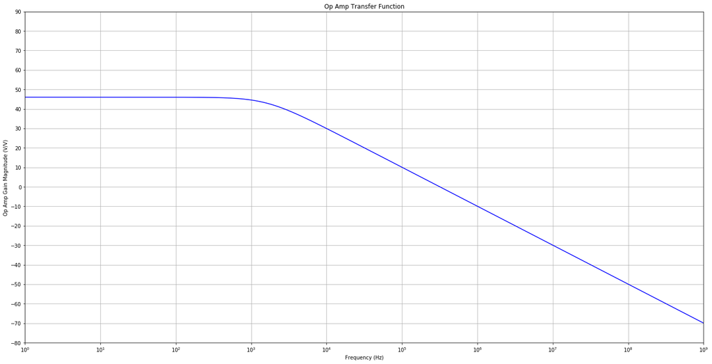

```python
# Op Amp Parameters
# -----------------
Gm = 2.0e-3 # Transconductance (S)
Ro = 1e5    # Output resistance (ohms)
Co = 1e-9   # Output capacitance (F)

fvec = geomspace(1.0, 1.0e9, 1000) # Frequency range (Hz)

Av = (Gm*Ro)/sqrt(1+(Ro*Co*2*pi*fvec)**2)
Av_dB = 20*log10(Av)

print("Op Amp DC Gain = {0:7.3f} (V/V)".format(Gm*Ro))
print("Op Amp DC Gain = {0:7.3f} (dB)".format(20*log10(Gm*Ro)))

f3dB = 1/(2*pi*Ro*Co)
print("Op Amp -3dB Frequency = {0:7.3f} (Hz)".format(f3dB))

figNum = 1
plt.figure(figNum,figsize=(24,12)) # Figure size in in. x in.
Av_curve,  =  plt.semilogx(fvec, Av_dB,   'b')
plt.axis([ 1.0, 1.0e9, -80, 90 ])
plt.xticks(geomspace(1.0,1.0e9,10)) # Tic marks every decade.
plt.yticks(np.arange(-80,100,10)) # Tic marks every 10 dB.
plt.grid(True)
plt.xlabel("Frequency (Hz)")
plt.ylabel("Op Amp Gain Magnitude (V/V)")
plt.title("Op Amp Transfer Function")
# plt.legend([ ID_curve, Itot_curve, IIN_curve ],[ 'Diode Current ID', 'Total Current Itot', 'Input Current IIN'])
plt.show()
```

*(Bode magnitude plot of opamp transfer function showing single-pole rolloff starting at cutoff frequency 1.6 kHz.)*

$$\left. \begin{aligned} V_G &= A_v(V_{REF} - V_f) = A_v\left(V_{REF} - \frac{R_2}{R_1 + R_2} V_{out}\right) \\ I_{DS} &= I_L + \underbrace{\frac{V_{out}}{R_1 + R_2}}_{\substack{\text{assume big} \\ \text{implies current} \\ \text{small}}} \approx I_L = \frac{\mu_n C_{ox}}{2} \left(\frac{W}{L}\right)_{N0} (V_{GS} - V_{T,n})^2 \\ V_{out} &\approx \left(1 + \frac{R_1}{R_2}\right) \left[ V_{REF} - \frac{1}{A_v} \left( \sqrt{\frac{I_{out}}{\frac{\mu_n C_{ox}}{2} \left(\frac{W}{L}\right)_{N0}}} + V_{T,n} \right) \right] \end{aligned} \right\} \text{Earlier Solution}$$

- At low frequency, $A_v = G_m R_o$, so

$$V_{out} \approx \left(1 + \frac{R_1}{R_2}\right) \left[ V_{REF} - \frac{1}{G_m R_o} \sqrt{\frac{I_{out}}{\frac{\mu_n C_{ox}}{2} \left(\frac{W}{L}\right)_{N0}}} - \frac{V_{T,n}}{G_m R_o} \right]$$$$\lim_{G_m R_o \rightarrow \infty} V_{out} = \left(1 + \frac{R_1}{R_2}\right) V_{REF}$$

- At high frequency, $\displaystyle A_v = \frac{G_m R_o}{1 + R_o C_o j\omega} \rightarrow A_v \approx \frac{G_m}{j\omega C_o} \rightarrow 0 \text{ as } \omega \rightarrow \infty$

$$V_{out} \approx \left(1 + \frac{R_1}{R_2}\right) \left( V_{REF} - \frac{j\omega C_o}{G_m} \left( \sqrt{\frac{I_{out}}{\frac{\mu_n C_{ox}}{2} \left(\frac{W}{L}\right)_{N0}}} + V_{T,n} \right) \right)$$

Bandwidth of linear regulator is set by bandwidth of opamp, if $C_{GS}$ of power FET can be neglected.

Not often true if $I_L$ can be large (need $W/L$ ratio for $N0$ large also).

### Resistor Feedback Network Design

```python
# Linear Regulator Specifications
# -------------------------------
VIN  = 1.8 # Input voltage (V)
VOUT = 1.0 # Output voltage (V)

ILmin =   0.1 # Minimum output current (mA)
ILmax = 100.0 # Maximum output current (mA)

IQspec = ILmin # Goal: total quiescent current equal to minimum load current.

# Voltage Reference
# -----------------
VBG  = 1.262  # Bandgap reference voltage (V)
VREF = VBG/2  # Reference voltage (V)

# Feedback Voltage Divider
# ------------------------
R1R2ratio = VOUT/VREF - 1
print("Feedback voltage divider R1/R2 ratio = {0:7.3f} (ohms/ohms)".format(R1R2ratio))

R1R2sum = VOUT/(IQspec*1e-3/2) # Allocate half the quiescent current to the feedback network.
print("\nFeedback voltage divider R1+R2 series resistance = {0:7.3f} (ohms)".format(R1R2sum))

R1 = R1R2sum/(1+(1/R1R2ratio))
R2 = R1R2sum - R1

print("\nFeedback voltage divider R1 resistance = {0:7.3f} (ohms)".format(R1))
print(  "Feedback voltage divider R2 resistance = {0:7.3f} (ohms)".format(R2))
```

```
Feedback voltage divider R1/R2 ratio =   0.585 (ohms/ohms)

Feedback voltage divider R1+R2 series resistance = 20000.000 (ohms)

Feedback voltage divider R1 resistance = 7380.000 (ohms)
Feedback voltage divider R2 resistance = 12620.000 (ohms)
```

### NMOS Power FET Design

Solving for NMOS $\frac{W}{L}$ ratio as a function of output (load) current and desired overdrive voltage:

$$ \left(\frac{W}{L}\right)_{\textrm{N0}} = \frac{I_{out}}{V_{ov}^{2} \frac{\mu_{N} C_{ox}}{2}} $$

```python
# 180 nm CMOS Transistor Parameters
# ---------------------------------
muCoxN = 387e-6 # NMOS process transconductance (A/V^2)
Vt0N   =    0.5 # NMOS nominal threshold voltage (V)
VAprimeN =    5 # NMOS Early voltage parameter (V/um)

muCoxP =  86e-6 # PMOS process transconductance (A/V^2)
Vt0P   =   -0.5 # PMOS nominal threshold voltage (V)
VAprimeP =    6 # NMOS Early voltage parameter (V/um)

# NMOS Power FET Design
# ---------------------
LN0  = 0.18         # Channel length (minimum) (um)
VAN0 = VAprimeN*LN0 # Early voltage (V)
print("NMOS N0 Early voltage (minimum length) = {0:7.3f} (V)".format(VAN0))

# Determine NMOS power FET width.

Vov   = 0.1 # Overdrive (V)
VGmax = 1.5 + 2*Vov # Limited by the opamp output swing.

WN0 = LN0*(ILmax*1.0e-3/((Vov**2)*(muCoxN/2)))
print("\nNMOS N0 width = {0:7.3f} (um)".format(WN0))

# DC Output Voltage
# -----------------
Av_DC = 50 # DC opamp open-loop gain (V/V)

Vo = (1+R1/R2)*VREF
print("\nOutput voltage (ideal opamp) = {0:7.3f} (Vo)".format(Vo))

Vo = (1+R1/R2)*( VREF - (1/Av_DC)*(sqrt(ILmax*1e-3 / ((muCoxN/2)*(WN0/LN0)) ) + Vt0N) )

print("\nOutput voltage (finite opamp gain) = {0:8.12f} (Vo)".format(Vo))
```

```
NMOS N0 Early voltage (minimum length) =   0.900 (V)

NMOS N0 width = 9302.326 (um)

Output voltage (ideal opamp) =   1.000 (Vo)

Output voltage (finite opamp gain) = 0.980982567353 (Vo)
```

**Single-Stage Op Amp**

[figure not shown]

$$\text{Differential gain } A_d = G_m R_o = g_{m,N1} (r_{o,N1} || r_{o,P0}) = A_v$$$$g_{m,N1} = \sqrt{2 \mu_n C_{ox} \frac{W}{L} I_D} = \sqrt{2 \mu_n C_{ox} \left(\frac{W}{L}\right)_{N1} \frac{I_{TAIL}}{2}} = \sqrt{\mu_n C_{ox} \left(\frac{W}{L}\right)_{N1} I_{TAIL}}$$$$r_{o,N1} = \frac{1}{\lambda_n I_D} = \frac{2}{\lambda_n I_{TAIL}}$$$$r_{o,P0} = \frac{1}{\lambda_p I_D} = \frac{2}{\lambda_p I_{TAIL}}$$

```python
# 180 nm CMOS Transistor Parameters
# ---------------------------------
muCoxN = 387e-6 # NMOS process transconductance (A/V^2)
Vt0N   =    0.5 # NMOS nominal threshold voltage (V)
VAprimeN =    5 # NMOS Early voltage parameter (V/um)

muCoxP =  86e-6 # PMOS process transconductance (A/V^2)
Vt0P   =   -0.5 # PMOS nominal threshold voltage (V)
VAprimeP =    6 # NMOS Early voltage parameter (V/um)

# Bias Current
# ------------
Itail  = IQspec / 2 # Allocate half the quiescent current to opamp bias current. Good idea?

# NMOS Differential Pair
# ----------------------
LN1 = 0.27          # Channel length (nonminimum) (um)
VAN1 = VAprimeN*LN1 # Early voltage (V)
print("NMOS N1 Early voltage (nonminimum length) = {0:7.3f} (V)".format(VAN1))

# Determine NMOS differential pair FET width.

Vov   = 0.1 # Overdrive (V)

WN1 = LN1*((Itail/2)*1.0e-3/((Vov**2)*(muCoxN/2)))
print("\nNMOS N1 width = {0:7.3f} (um)".format(WN1))

gmN1 = sqrt(muCoxN*(WN1/LN1)*Itail*1e-3)
print("\nNMOS N1 gm = {0:7.3f} (uA/V)".format(gmN1/1e-3))

roN1 = VAN1/((Itail/2)*1.0e-3)
print("\nNMOS N1 ro = {0:7.3f} (ohms)".format(roN1))

# Calculate gain assuming PMOS P0 output resistance same as NMOS N1 (for now)
Av0 = gmN1*(roN1/2)
print("\nOpamp Gain Av = {0:7.3f} (V/V)".format(Av0))

# Calculate output voltage with one-stage opamp gain
Vo = (1+R1/R2)*( VREF - (1/Av0)*(sqrt(ILmax*1e-3 / ((muCoxN/2)*(WN0/LN0)) ) + Vt0N) )

print("\nOutput voltage (single-stage finite opamp gain) = {0:8.12f} (Vo)".format(Vo))
```

```
NMOS N1 Early voltage (nonminimum length) =   1.350 (V)

NMOS N1 width =   3.488 (um)

NMOS N1 gm =   0.500 (uA/V)

NMOS N1 ro = 54000.000 (ohms)

Opamp Gain Av =  13.500 (V/V)

Output voltage (single-stage finite opamp gain) = 0.929565064272 (Vo)
```

### SHUNT REGULATOR

[figure not shown]

Adjust $I_{shunt}$ s.t. $V_{out} = V_{in} - R_{in}(I_L + I_{shunt}) = V_{REF}$

Need $V_{in} - R_{in} I_{L,max} \ge V_{REF}$ since $I_{shunt} \ge 0\text{ A}$.

$$\text{Best case efficiency : } V_{in} - R_{in} I_{L,max} = V_{out}$$

$$P_{out} = V_{out} I_{L,max}$$$$P_{in} = V_{in} I_{L,max}$$

$$P_{in} = V_{out} I_{L,max} + I_{L,max}^2 R_{in}$$$$\eta = \frac{P_{out}}{P_{in}} = \frac{V_{out} I_{L,max}}{V_{out} I_{L,max} + I_{L,max}^2 R_{in}}$$$$\phantom{\eta = \frac{P_{out}}{P_{in}}} = \frac{1}{1 + \frac{I_{L,max} R_{in}}{V_{out}}} = \frac{1}{1 + \frac{R_{in}}{R_{L(min)}}}$$

**Source Follower Output Stage**

[figure not shown]

# High-Voltage Tolerant FETs

FET structures modified to limit the electric field due to the applied voltages to be below the critical (breakdown) field.

### Drain-Extended MOS (DEMOS)

[figure not shown]

Lateral field from drain to source is (mostly) dropped across drain-extended diffusion region.

Tradeoff between maximum $V_{DS}$ and on resistance of the MOSFET.

Increasing the drain extension length increases both. (Also increases device area and increases drain junction parasitic capacitance).

Typical Maximum Voltages:

- Maximum gate-source voltage $V_{GS\textrm{,max}} \geq V_{GS}$
- Maximum gate-drain voltage $V_{GD\textrm{,max}} \geq V_{GD}$ and $V_{GD\textrm{,max}} > V_{GS\textrm{,max}}$
- Maximum drain-source voltage $V_{DS\textrm{,max}} \geq V_{DS}$

Often set by oxide breakdown limitations

### Drain-Extended MOSFET Symbols

Note: Symbols are asymmetric with respect to source and drain.

[figure not shown]

### Lateral Double-Diffused MOS (LDMOS)

[figure not shown]

LDMOS structure has advantage of low on-resistance and high drain-source and/or gate-drain breakdown voltages.

Often applied to RF power amplifier designs

### Double-Diffused Drain MOS (DDDMOS)

[figure not shown]

Symmetric structure compared to DEMOS.